# dataOhlsson Frequency

## Quantile Plot

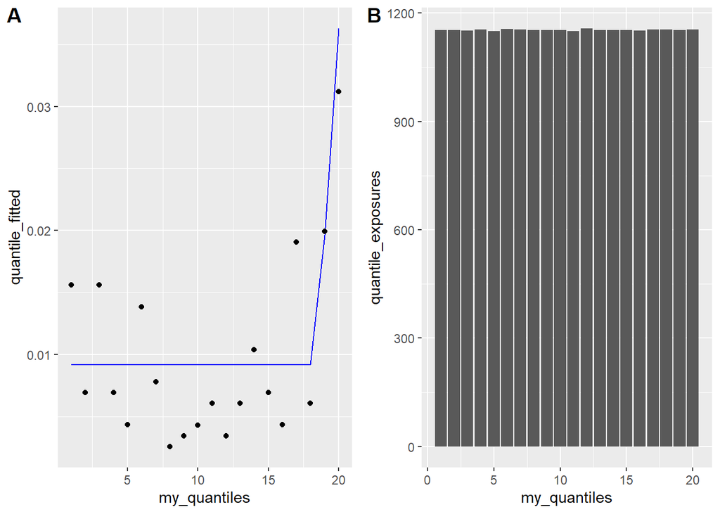

```r
quantile_plot <- function(predictions1,claims1,exposures1,n = 20){
  table<-data.frame(predictions = predictions1,
                    claims = claims1,
                    exposures = exposures1)
  total_expos <- sum(table$exposures)

  table2 <- table %>%
    mutate(fit_freq = predictions/exposures) %>%
    arrange(fit_freq) %>%
    mutate(running_total = cumsum(exposures)) %>%
    mutate(my_quantiles = floor(n * running_total/total_expos)+1) %>%
    mutate(my_quantiles = if_else(my_quantiles > n, n, my_quantiles)) %>%
    ungroup()

  table3 <- table2 %>%
    group_by(my_quantiles) %>%
    summarize(quantile_fitted = sum(predictions)/sum(exposures),
              quantile_actual = sum(claims)/sum(exposures),
              quantile_exposures = sum(exposures),
              .groups = 'drop') %>%
    ungroup()

  quant_plot1 <- ggplot(table3) +
    geom_line(aes(x = my_quantiles, y = quantile_fitted),col="blue") +
    geom_point(aes(x = my_quantiles, y = quantile_actual),col="black")

  quant_plot2 <- ggplot(table3) +
    geom_col(aes(x = my_quantiles, y = quantile_exposures))

  plot_grid(quant_plot1, quant_plot2, labels = "AUTO")
}

# Quantile plots on holdout data

quantile_plot(dataOhlsson_test$glm_underfit_fitted_values,
              dataOhlsson_test$claims,
              dataOhlsson_test$exposures)
```

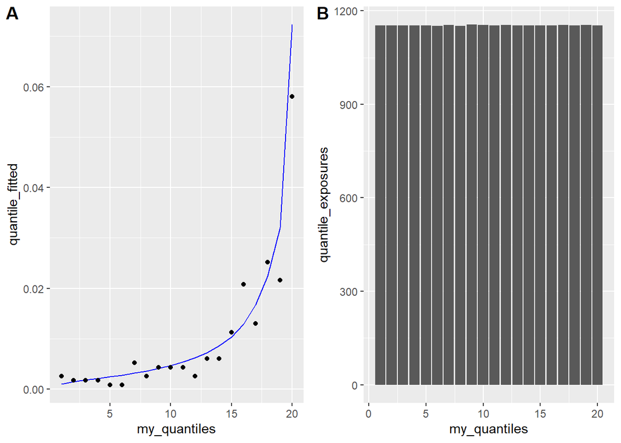

```r
quantile_plot(dataOhlsson_test$glm_int_fitted_values,
              dataOhlsson_test$claims,
              dataOhlsson_test$exposures)
```

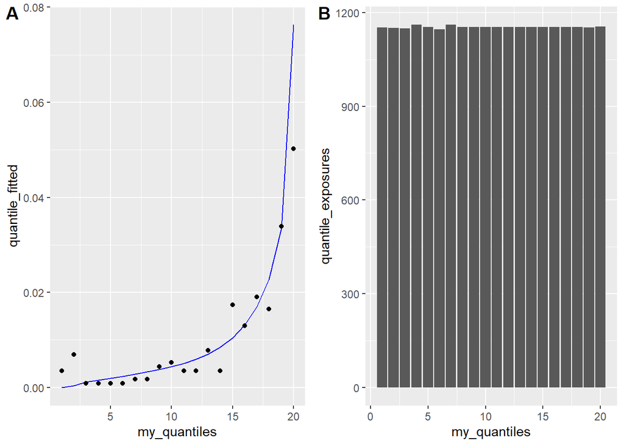

```r
quantile_plot(dataOhlsson_test$glm_overfit_fitted_values,
              dataOhlsson_test$claims,
              dataOhlsson_test$exposures)
```

## Double Lift Charts

A double lift chart is a way to compare 2 candidate models. A double lift chart highlights the records in the leftmost and rightmost bins as the areas where the models disagree the most. The model that matches the observed frequency better is the better model.

Here is a how a double lift chart works in words: + Predictions are made on both models + A ratio between the model predictions is calculated + We bucket the ratio into quantiles + We compare model 1 predictions vs model 2 predictions vs the actual + The model that matches actual better is the preferred model

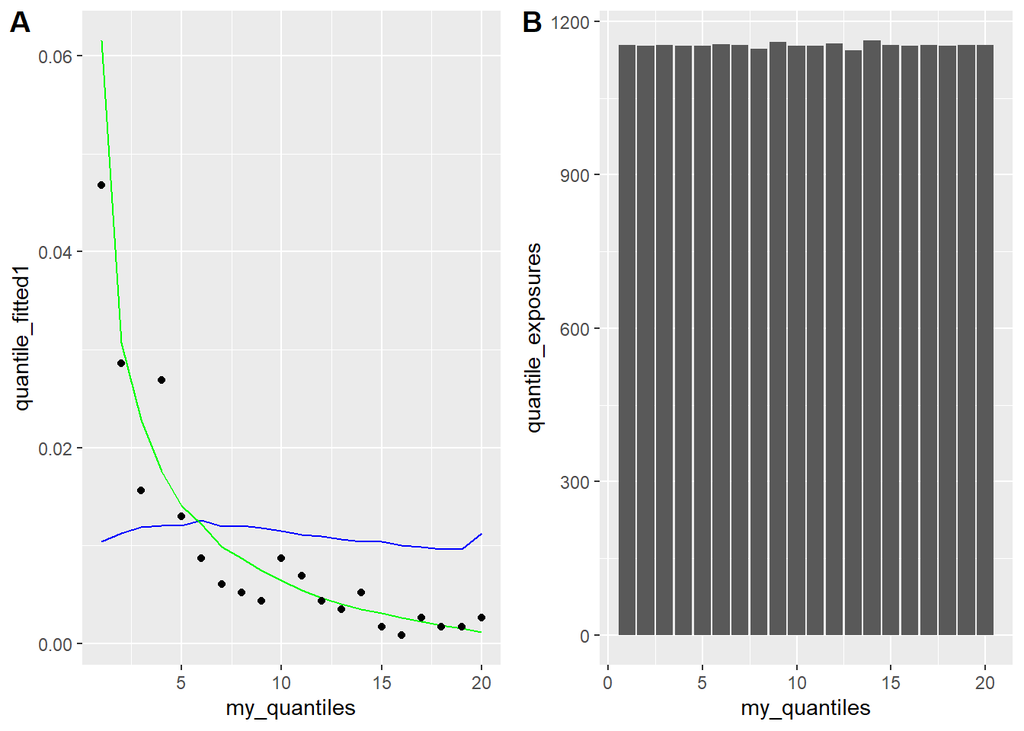

```r
double_lift <- function(predictions_1, predictions_2, claims1, exposures1,n = 20){
  table<-data.frame(predictions1 = predictions_1,
                    predictions2 = predictions_2,
                    claims = claims1,
                    exposures = exposures1)
  total_expos <- sum(table$exposures)

  table2 <- table %>%
    mutate(fit_freq1 = predictions1/exposures,
           fit_freq2 = predictions2/exposures) %>%
    mutate(fit_ratio = fit_freq1/fit_freq2) %>%
    arrange(fit_ratio) %>%
    mutate(running_total = cumsum(exposures)) %>%
    mutate(my_quantiles = floor(n * running_total/total_expos)+1) %>%
    mutate(my_quantiles = if_else(my_quantiles > n, n, my_quantiles)) %>%
    ungroup()

  table3 <- table2 %>%
    group_by(my_quantiles) %>%
    summarize(quantile_fitted1 = sum(predictions1)/sum(exposures),
              quantile_fitted2 = sum(predictions2)/sum(exposures),
              quantile_actual = sum(claims)/sum(exposures),
              quantile_exposures = sum(exposures),
              .groups = 'drop') %>%
    ungroup()

  quant_plot1 <- ggplot(table3) +
    geom_line(aes(x = my_quantiles, y = quantile_fitted1),col="blue") +
    geom_line(aes(x = my_quantiles, y = quantile_fitted2),col="green") +
    geom_point(aes(x = my_quantiles, y = quantile_actual),col="black")

  quant_plot2 <- ggplot(table3) +
    geom_col(aes(x = my_quantiles, y = quantile_exposures))

  plot_grid(quant_plot1, quant_plot2, labels = "AUTO")
}

double_lift(dataOhlsson_test$glm_underfit_fitted_values, # blue
            dataOhlsson_test$glm_int_fitted_values, # green
            dataOhlsson_test$claims,
            dataOhlsson_test$exposures,
            n = 20)
```

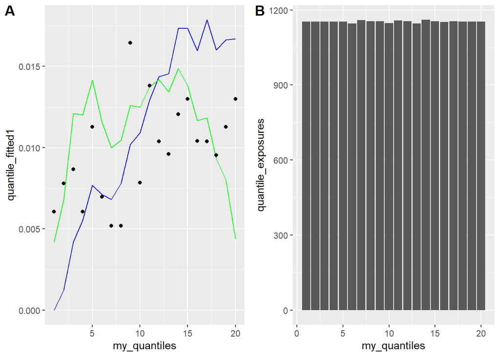

```r
double_lift(dataOhlsson_test$glm_overfit_fitted_values, # blue
            dataOhlsson_test$glm_int_fitted_values, # green
            dataOhlsson_test$claims,
            dataOhlsson_test$exposures,
            n = 20)
```

## Final Conclusion

The glm with the interaction and the overfit glm looked the best. Ultimately I would argue that the glm with the interaction is better, for the following reasons:

- The AIC for the glm with the interaction was lower
- The deviance on test data was lower for the glm with the interaction
- The quantile plot for the overfit glm looked like it was overfitting low and high quantiles more
- The double lift chart appeared to be sort of a draw, which ultimately favors the smaller model